# Final Project: Geospatial Groundwater Interpolation & Analysis

Programming for GIS  
Mikaela Bollag-Miller  
April 28th, 2025

# Introduction: Background and Motivation

Groundwater holds a third of all freshwater resources and locally accounts for the sole source of drinking water in Missoula, MT (Pracht, 2001; Taylor et al., 2013). In the context of climate changes, this essential resource is impacted in complex and uncertain ways. Anthropogenically-driven climate change alters hydraulic cycling, with precipitation patterns in the western United States revealing a shift toward more arid conditions (Carroll et al., 2024; Meixner et al., 2016; Taylor et al., 2013). In the intermountain west, this is evidenced by declining snowpack and streamflow as well as earlier peak snowmelt and streamflow (Barnett et al., 2005; Mote et al., 2005). These hydrologic shifts create greater uncertainty in the quantity and timing of groundwater recharge from mountain aquifers to populated valleys (Markovich et al., 2021; Meixner et al., 2016; Taylor et al., 2013).

The Missoula Aquifer (MA) underlying the Missoula Valley in western Montana is the designated sole-source alluvial aquifer which supports the local population of nearly 80,000 people (Miller, 2001). Despite increasing regional efforts to quantify groundwater resources, the MA remains poorly understood, with temporal and spatial variability of groundwater resources lacking modern analysis since modeling efforts in the early 2000s (LaFave, 2002; Miller, 2001; Pracht, 2001). The Missoula Valley provides a hydrologic system with geology characteristic of the intermountain west and access to high-quality down-basin monitoring well data.

Predictions of declining groundwater storage in the mountain west increase the urgency to better understand and quantify groundwater resources (Barnett et al., 2004; Carroll et al., 2024). Investigating the spatial and seasonal variability of groundwater in the MA will inform local groundwater vulnerability and resilience and thus provide a finer timescale for forecasted declines.

# Hypotheses and Research Questions:

#### Research Questions

- What is the spatial variation in groundwater level in the Missoula Aquifer (MA)?
- How does this variation correlate with river corridors?
- How does MA groundwater level spatially vary between seasons?

#### Hypotheses

- MA groundwater level will vary spatially with river corridors: higher levels will occur close to river corridors.
- MA groundwater level will vary with season. Higher levels will occur during seasonally wet times (spring).

# Technical Approach (1):

### Overall workflow

This project conducts a preliminary spatiotemporal analysis of the Missoula Aquifer (MA) underlying the Missoula Valley using point-based monitoring well data. The primary output is a groundwater surface map for the MA with uncertainty estimates. The workflow consists of **three major steps: data gathering and preprocessing, geospatial interpolation using Kriging, and visualization of water levels alongside uncertainty estimates.**

### Data Gathering & Preprocessing

#### Data Sources:

- **Well Data:** Monthly averaged groundwater elevations from 19 continuously monitored wells, including spatial location information. Sourced from the Missoula County Department of Public Health
- **River Data:** Vector polylines representing major river corridors in the Missoula Valley, sourced from Missoula County GIS services.

Daily groundwater elevation data were aggregated into monthly means to reduce noise and highlight seasonal patterns. The well network maintained by the Missoula County Department of Public Health provides spatial coverage across the valley and includes wells screened at varying depths within the Missoula Aquifer.

River corridor spatial data were incorporated to provide hydrologic context for interpreting groundwater patterns and to allow direct spatial comparison between groundwater surfaces and these surface water features.

#### Data Preprocessing:

Initial exploratory data visualization of groundwater elevations and relative changes at each well were conducted first to assess variability between wells and through time. Then to enable consistent geospatial interpolation, well locations were reprojected to a UTM coordinate system (EPSG:26912). The river spatial data were reprojected to match. A buffered bounding box around the wells was created to define a consistent interpolation and plotting extent across the study area.

# 1. Setup and Installation

Before running this notebook, ensure that all required Python packages are installed.

### Import Libraries

After installing the packages, import the necessary libraries for data analysis, geospatial transformations, interpolation, and plotting.

### Environment Information:

[output not shown]

### 2. Download and Data Preparation:

All required data for this project are included in the provided `.zip` archive.

#### Data Extraction and Loading

- The `wells_month.zip` file is extracted to a working directory `wells_month_data/`.
- The primary well dataset (`wells_month.csv`) is loaded as a GeoDataFrame
- Additional River streams shapefile is loaded: (`Streams24K_NamedOnly.shp`)

All datasets are first projected into WGS84 geographic coordinates (`EPSG:4326`) for spatial comparison

**Note: During shapefile loading, a warning may issue regarding Measured 3D LineStrings. Disregard, this does not impact this analysis.**

```
/opt/anaconda3/envs/dataprocess/lib/python3.13/site-packages/pyogrio/raw.py:198: UserWarning: Measured (M) geometry types are not supported. Original type 'Measured 3D LineString' is converted to 'LineString Z'
  return ogr_read(
```

#### 3. Data Preprocessing

The objectives of this section are to prepare the well and river data for visualizations and then geospatial interpolation.

- Calculate the **relative water level change** over time for each well. (**Relative changes** are computed by subtracting the initial month's value (baseline = 0) from subsequent months.)
- Clip river data to study area spatial extent

**Note:** Missing monthly observations are recorded as `NaN`.

#### 4. Primary Visualization: Well Data

Three initial plots were made to explore point temporal groundwater dynamics in the well data and the spatial relationship between wells and river corridors.

1. **Monthly averaged absolute water level elevation** for each well over 2024.
2. **Relative change** in water level elevation, normalized to each well's initial observation.
3. **River data** were mapped onto monitoring well locations

Note: A consistent color is assigned to each well to allow for comparison across plots.

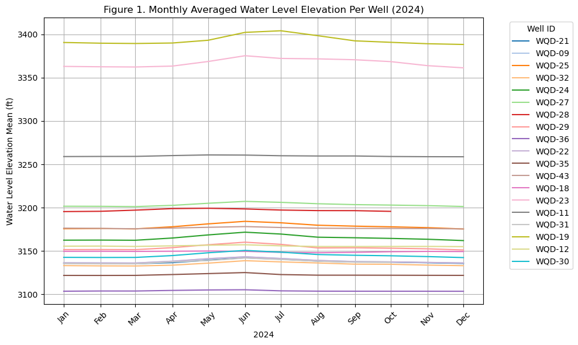

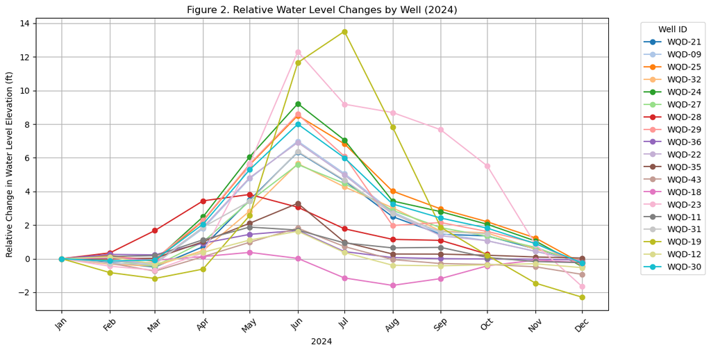

### 5. Spatial Analysis: Buffering and Clipping Rivers

This section focuses on spatial analysis of wells and nearby rivers:

- Wells are reprojected to a projected CRS (EPSG:3857) to allow buffering in meters.
- A 5,000-meter buffer is created around all wells.
- Rivers are spatially clipped to the extent of the buffer.
- A map is produced showing the wells and clipped river segments with consistent well coloring.

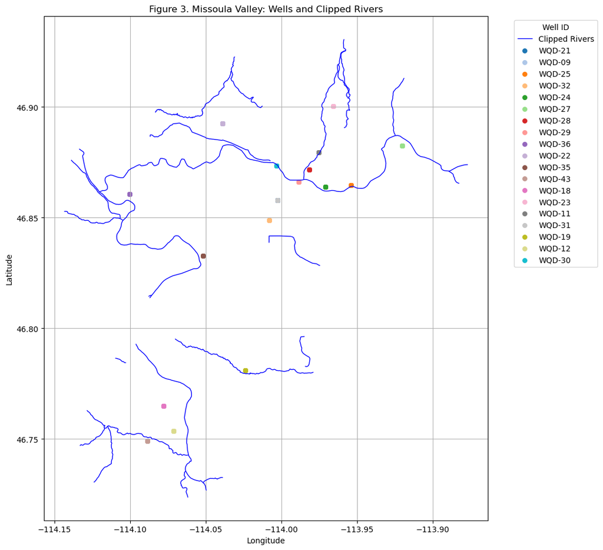

# Technical Approach (2):

### Spatial Interpolation

Groundwater elevation data were interpolated across the study area using Ordinary Kriging, a geostatistical interpolation technique that models spatial relationships to estimate values at unsampled locations. In this application, kriging is used to predict groundwater levels for unsampled locations based on point measurements (well data). Ordinary Kriging was chosen because it provides both predicted values and associated uncertainty, allowing for greater understanding of groundwater surface predictions and variability.The groundwater level interpolation was executed over a uniform grid of 300 × 300 points spanning the chosen study extent.

The outputs of the Kriging analysis included:

- **Predicted Groundwater Surface Map:** A continuous elevation surface showing predicted groundwater heights across the valley.
- **Variance Map:** A map of Kriging prediction uncertainty, showing areas of higher and lower confidence based on well proximity and density.

### Final Data Visualization

The interpolated groundwater surface was plotted as a filled contour map with overlaid well locations. The variance map was plotted similarly to assess spatial patterns of uncertainty.

The kriged groundwater surface was then overlaid with river corridors to allow spatial comparison. River features were labeled for clarity, and a north arrow was added to facilitate map orientation.

Both maps were produced for February 2024 as a case study. In future analysis, additional seasonal maps will be generated to assess seasonal groundwater dynamics.

#### 4. Spatial Interpolation Preparation:

- Prepare groundwater and river data by setting a consistent spatial extent (`global_bbox`), computing color scaling bounds, and reprojecting to UTM Zone 12N (EPSG:26912)
- Perform spatial interpolation using Ordinary Kriging: filter well data by month, extract UTM coordinates and water level elevations, create a uniform grid over the study area, and generate predicted water surface and uncertainty maps.

#### 5. Spatial Interpolation: Visualizing Kriging Results

- Define contour levels for interpolated water level elevations based on global minimum and maximum values.
- Use a custom color map (Color Brewer) for visualizing the Kriged water surface.
- Plot the Kriging interpolation results over consitent spatial grid, overlaying observed well locations and data.
- Generate a separate uncertainty (variance) map using a red color map to display Kriging interpolation error.

**Example Data: Februrary 2024**

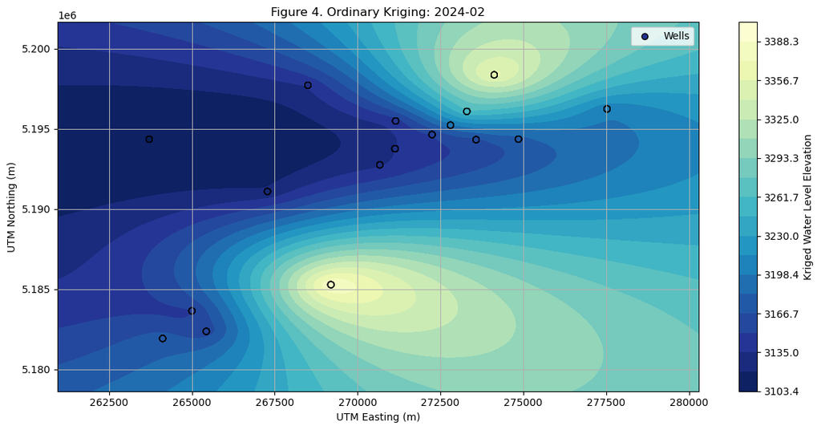

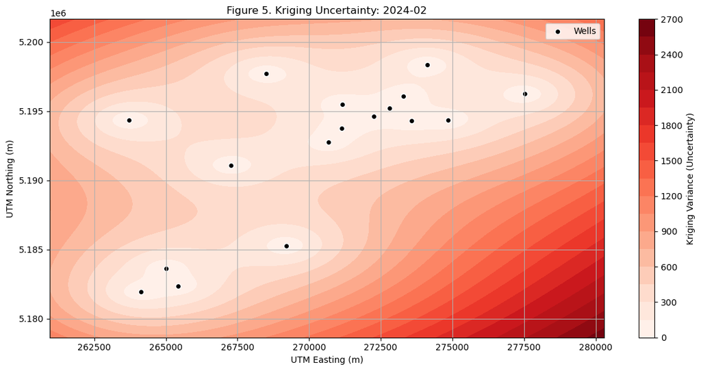

##### 6. Kriging Interpolation with River Overlay

- Plot the Kriging-predicted water level surface
- Overlay observed wells and river features, labeling rivers by name.
- Add layout features: a north arrow, a colorbar, legend, and general layout adjustments

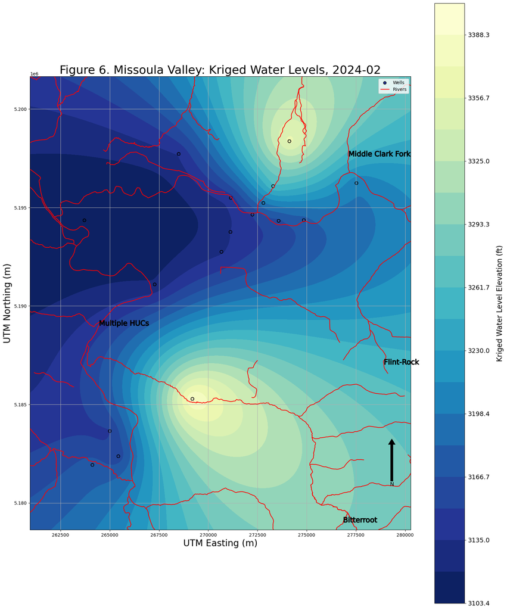

# Technical Approach (3):

### Incorperating “Best Practices for Scientific Computing”

In developing this project, a few of the "best practices for scientific computing" were applied to work on reproducibility, clarity, and efficiency. Several functions were created to automate repetitive and complex tasks, such as spatial interpolation and plotting. With these functions in place, this workflow can be easily applied to different months or datasets. Code readability was attempted through consistent and meaningful variable names. AI-based tools were applied to improve standardization in formatting and code style. The project goals, which contained a lot of data preprocessing, forced working incrementally with frequent evaluation of outputs to view bugs and errors. Writing more simplified and modular code "for people" (i.e huge and complex plot_kriging_with_rivers function) is certaintly an area for imporvement in future projects.

# Conclusion

To bolster this seasonal groundwater analysis, future work will produce spatially interpolated groundwater level maps for each month and season, incorporating the complexity of spatial variability. In order to better capture subtle groundwater fluctuations across the valley, methods to normalize water level elevations between wells will be necessary. Minor shifts in groundwater levels are currently masked by the large absolute elevation range under the existing interpolation methods (See Figure 1).

Given the tightly coupled surface-water and groundwater systems in this region, it is possible that these groundwater elevation patterns reflect areas where groundwater is either discharging into rivers (low elevation areas) or recharging from rivers (groundwater high points) (Pracht, 2001). Another important factor likely influencing spatial variation is human groundwater extraction. Although the monitoring wells used in this analysis are not active pumping wells, nearby pumping may impact local groundwater gradients, potentially driving some of the spatial patterns observed. To strengthen the surface-groundwater spatial analysis in future work, additional data on known groundwater pumping locations and rates, as well as river discharge measurements, should be incorporated. Including broader spatial context, such as valley and aquifer boundaries, mountain topography, and local landmarks, would also enhance the interpretation of these groundwater surface patterns and maps.

The Kriging variance map (Figure 5) provides insight into data coverage across the Missoula Valley. Higher Kriging uncertainty (variance) is observed in regions farther from observed data (well locations), particularly along the southeast and northwest valley margins. These findings highlight areas of data sparsity and can inform future data collection efforts as Missoula County expands their groundwater monitoring well network.